# Extinct Plants

This dataset came out August 18, 2020 (I got it a day early). The page is [here](https://github.com/rfordatascience/tidytuesday/blob/master/data/2020/2020-08-18/readme.md). The GitHub page also provides three links for more information:

- The [IUCN main page](https://www.iucnredlist.org/)
- A [study published in 2019](https://advances.sciencemag.org/content/5/11/eaax9444)
- An [IUCN blog post](https://www.iucn.org/news/species/201909/over-half-europes-endemic-trees-face-extinction)

It’s a little late, so I’m going to make a good round start tonight, mostly reading and doing the typical data skim with `skimr::skim()`.

# Background

Question: What is the IUCN Red List?

> Established in 1964, The International Union for Conservation of Nature’s Red List of Threatened Species has evolved to become the world’s most comprehensive information source on the global conservation status of animal, fungi and plant species. The IUCN Red List is a critical indicator of the health of the world’s biodiversity. Far more than a list of species and their status, it is a powerful tool to inform and catalyze action for biodiversity conservation and policy change, critical to protecting the natural resources we need to survive. It provides information about range, population size, habitat and ecology, use and/or trade, threats, and conservation actions that will help inform necessary conservation decisions.

This is from the IUCN Red List website. Also on their website is a brief tally of species threatened by extinction.

- 41% of amphibians
- 26% of mammals
- 34% of conifers
- 14% of birds
- 30% of sharks and rays
- 33% of reef corals
- 28% of selected crustaceans
- 27% of all assessed species; that’s more than 32,000 species threatened with extinction.

The data I’m working with deals with plants, i.e. anything in the kingdom Plantae. My best guess is that most endangered species are flowering plants, but I’m not surprised that conifers have such a high rate of going extinct. There are very few species of gymnosperms compared to the flowering plants, and they often have very specific living conditions. They are usually trees, which makes them targets of deforestation.

# The Data

The data comes from the International Union for Conservation of Nature (IUCN) Red List of Threatened Species (Version 2020-1). It was prepared by Florent Lavergne for his [infographic](https://www.behance.net/gallery/98304453/Infographic-Plants-in-Danger).

## Getting the data

```r
plants <- readr::read_csv('https://raw.githubusercontent.com/rfordatascience/tidytuesday/master/data/2020/2020-08-18/plants.csv')
actions <- readr::read_csv('https://raw.githubusercontent.com/rfordatascience/tidytuesday/master/data/2020/2020-08-18/actions.csv')
threats <- readr::read_csv('https://raw.githubusercontent.com/rfordatascience/tidytuesday/master/data/2020/2020-08-18/threats.csv')
save(plants, actions, threats, file = "data/extinct_plants.RData")
```

The data dictionaries for these are obviously long, so I will reference them when necessary. The data is organized into three data sets.

1. `plants`: In this data set, the unit of observation is the plant. For each plant, each variable describes one of the plant’s characteristics. Examples include the country of origin, the taxonomic group, indicators for whether the plant is threatened by a given threat, and indicators for whether the plant is the target of a given conservation action.

| binomial_name | country | continent | group | year_last_seen | threat_AA | threat_BRU | threat_RCD | threat_ISGD | threat_EPM | threat_CC | threat_HID | threat_P | threat_TS | threat_NSM | threat_GE | threat_NA | action_LWP | action_SM | action_LP | action_RM | action_EA | action_NA | red_list_category |
| --- | --- | --- | --- | --- | --- | --- | --- | --- | --- | --- | --- | --- | --- | --- | --- | --- | --- | --- | --- | --- | --- | --- | --- |
| Abutilon pitcairnense | Pitcairn | Oceania | Flowering Plant | 2000-2020 | 0 | 0 | 0 | 1 | 0 | 0 | 0 | 0 | 0 | 0 | 1 | 0 | 1 | 1 | 0 | 1 | 0 | 0 | Extinct in the Wild |
| Acaena exigua | United States | North America | Flowering Plant | 1980-1999 | 0 | 0 | 0 | 1 | 0 | 0 | 0 | 0 | 0 | 0 | 0 | 0 | 0 | 0 | 0 | 1 | 0 | 0 | Extinct |
| Acalypha dikuluwensis | Congo | Africa | Flowering Plant | 1940-1959 | 0 | 0 | 0 | 0 | 1 | 0 | 0 | 0 | 0 | 0 | 0 | 0 | 0 | 0 | 0 | 0 | 0 | 1 | Extinct |
| Acalypha rubrinervis | Saint Helena, Ascension and Tristan da Cunha | Africa | Flowering Plant | Before 1900 | 1 | 1 | 0 | 1 | 0 | 0 | 0 | 0 | 0 | 0 | 0 | 1 | 0 | 0 | 0 | 0 | 0 | 1 | Extinct |
| Acalypha wilderi | Cook Islands | Oceania | Flowering Plant | 1920-1939 | 1 | 0 | 1 | 1 | 0 | 0 | 0 | 0 | 1 | 0 | 0 | 0 | 0 | 0 | 0 | 0 | 0 | 1 | Extinct |
| Acer hilaense | China | Asia | Flowering Plant | 1920-1939 | 0 | 0 | 1 | 0 | 0 | 0 | 0 | 0 | 0 | 0 | 0 | 0 | 0 | 1 | 0 | 0 | 0 | 0 | Extinct in the Wild |

2. `actions`: The unit of observation is the action/plant combination. In other words, this is simply a fully interacted version of the `plants` data set.

| binomial_name | country | continent | group | year_last_seen | red_list_category | action_type | action_taken |
| --- | --- | --- | --- | --- | --- | --- | --- |
| Abutilon pitcairnense | Pitcairn | Oceania | Flowering Plant | 2000-2020 | Extinct in the Wild | Land & Water Protection | 1 |
| Abutilon pitcairnense | Pitcairn | Oceania | Flowering Plant | 2000-2020 | Extinct in the Wild | Species Management | 1 |
| Abutilon pitcairnense | Pitcairn | Oceania | Flowering Plant | 2000-2020 | Extinct in the Wild | Law & Policy | 0 |
| Abutilon pitcairnense | Pitcairn | Oceania | Flowering Plant | 2000-2020 | Extinct in the Wild | Research & Monitoring | 1 |
| Abutilon pitcairnense | Pitcairn | Oceania | Flowering Plant | 2000-2020 | Extinct in the Wild | Education & Awareness | 0 |
| Abutilon pitcairnense | Pitcairn | Oceania | Flowering Plant | 2000-2020 | Extinct in the Wild | Unknown | 0 |

3. `threats`: The unit of observation is the threat/species combination, similar to the `actions` data set.

| binomial_name | country | continent | group | year_last_seen | red_list_category | threat_type | threatened |
| --- | --- | --- | --- | --- | --- | --- | --- |
| Abutilon pitcairnense | Pitcairn | Oceania | Flowering Plant | 2000-2020 | Extinct in the Wild | Agriculture & Aquaculture | 0 |
| Abutilon pitcairnense | Pitcairn | Oceania | Flowering Plant | 2000-2020 | Extinct in the Wild | Biological Resource Use | 0 |
| Abutilon pitcairnense | Pitcairn | Oceania | Flowering Plant | 2000-2020 | Extinct in the Wild | Commercial Development | 0 |
| Abutilon pitcairnense | Pitcairn | Oceania | Flowering Plant | 2000-2020 | Extinct in the Wild | Invasive Species | 1 |
| Abutilon pitcairnense | Pitcairn | Oceania | Flowering Plant | 2000-2020 | Extinct in the Wild | Energy Production & Mining | 0 |
| Abutilon pitcairnense | Pitcairn | Oceania | Flowering Plant | 2000-2020 | Extinct in the Wild | Climate Change | 0 |

The latter two data sets are derivable from the plants dataset, so let me look there first.

```r
skimr::skim(plants)
```

```
-- Data Summary ------------------------
                           Values
Name                       plants
Number of rows             500
Number of columns          24
_______________________
Column type frequency:
  character                6
  numeric                  18
________________________
Group variables            None

-- Variable type: character ---------------------------------------------------------------------------------------
# A tibble: 6 x 8
  skim_variable     n_missing complete_rate   min   max empty n_unique whitespace
* <chr>                 <int>         <dbl> <int> <int> <int>    <int>      <int>
1 binomial_name             0          1       11    35     0      500          0
2 country                   0          1        4    44     0       72          0
3 continent                 0          1        4    13     0        6          0
4 group                     0          1        5    16     0        6          0
5 year_last_seen           15          0.97     9    11     0        7          0
6 red_list_category         0          1        7    19     0        2          0

-- Variable type: numeric -----------------------------------------------------------------------------------------
# A tibble: 18 x 11
   skim_variable n_missing complete_rate  mean     sd    p0   p25   p50   p75  p100 hist
 * <chr>             <int>         <dbl> <dbl>  <dbl> <dbl> <dbl> <dbl> <dbl> <dbl> <chr>
 1 threat_AA             0             1 0.454 0.498      0     0     0     1     1 ▇▁▁▁▆
 2 threat_BRU            0             1 0.306 0.461      0     0     0     1     1 ▇▁▁▁▃
 3 threat_RCD            0             1 0.172 0.378      0     0     0     0     1 ▇▁▁▁▂
 4 threat_ISGD           0             1 0.162 0.369      0     0     0     0     1 ▇▁▁▁▂
 5 threat_EPM            0             1 0.09  0.286      0     0     0     0     1 ▇▁▁▁▁
 6 threat_CC             0             1 0.068 0.252      0     0     0     0     1 ▇▁▁▁▁
 7 threat_HID            0             1 0.04  0.196      0     0     0     0     1 ▇▁▁▁▁
 8 threat_P              0             1 0.028 0.165      0     0     0     0     1 ▇▁▁▁▁
 9 threat_TS             0             1 0.022 0.147      0     0     0     0     1 ▇▁▁▁▁
10 threat_NSM            0             1 0.206 0.405      0     0     0     0     1 ▇▁▁▁▂
11 threat_GE             0             1 0.036 0.186      0     0     0     0     1 ▇▁▁▁▁
12 threat_NA             0             1 0.214 0.411      0     0     0     0     1 ▇▁▁▁▂
13 action_LWP            0             1 0.13  0.337      0     0     0     0     1 ▇▁▁▁▁
14 action_SM             0             1 0.116 0.321      0     0     0     0     1 ▇▁▁▁▁
15 action_LP             0             1 0.058 0.234      0     0     0     0     1 ▇▁▁▁▁
16 action_RM             0             1 0.054 0.226      0     0     0     0     1 ▇▁▁▁▁
17 action_EA             0             1 0.002 0.0447     0     0     0     0     1 ▇▁▁▁▁
18 action_NA             0             1 0.758 0.429      0     1     1     1     1 ▂▁▁▁▇
```

There are 500 plant species from 72 countries of origin on 6 out of 7 continents. Most, I would guess, are flowering plants. There are two possible ‘red list’ categories: extinct and extinct in the wild. The means of the numeric variables provide a convenient way of seeing how they are distributed. For example, almost half the species are threatened by agriculture and aquaculture (AA), while only 4% were threatened by human intrusions (HID). A species may be threatened by one or more different threats. A shocking figure is that only 0.2% of the species (that’s 1 out of all 500) were the target of education and awareness action. In fact, actions are few; 76% have no action to save them registered. (The NA action is, I’m guessing, exclusive of all the other actions.)

It’s easier to understand the data if you know what plant groups are considered here.

```r
plants %>%
  tabyl(group)
```

```
            group   n percent
            Algae   3   0.006
          Conifer   1   0.002
            Cycad   8   0.016
 Ferns and Allies  13   0.026
  Flowering Plant 471   0.942
           Mosses   4   0.008
```

The results here are somewhat surprising. There is only one conifer listed, despite 34% of conifers being endangered. Ferns and fern allies represent the second largest category after flowering plants, which I’m happy to see. And the mosses have a good showing as well.

Okay, so I have a sense of the data now. Before I go any further, I’m going to flesh out the ‘background’ section using the links the Tidy team offered.

# Questions

There are a million questions I want to ask about this topic, of course, but let me stay very limited. What is the leading cause of extinction? What plant families get the most attention? For that one, I’ll need to match each species to its full scientific name, which could be a task given how rare some of these are. But I’m very interested in finding a database of plant names for just that purpose.

I have country of origin information, so I could plot the density by country (like [this twitter post](https://twitter.com/JDavison_/status/1295385653593743361)). I could explore a number of topics this way, but because it’s on a global scale I don’t think I would find it satisfying.

If I could merge in extra plant data, that would be the most satisfying, I think. Which habitats are most endangered? Why the tropics? Where were these plants last recorded in the wild? In large numbers? That might be asking a lot. I shoud perhaps limit myself at first.

I don’t have a good dictionary of styles of dictionaries. One that I like, though, is the long graphic made up of a bunch of rows, each with a circle that gets filled in when a certain characteristic is present. Let me try to make one of these myself, and then I’ll look at some source code.

One style is the raster grid (see [here](https://twitter.com/kllycttn/status/1295771562319257610)). Someone mentioned the `waffle` package in conjunction with a raster-style graphic like this. Yeah, I would like to learn more about this package; it looks interesting, at least.

Another is [this](https://twitter.com/MaiaPelletier/status/1295762163118858240) graphic with really nice dot-style data visualizing. This same person mentioned the package `extrafont` which seems like it makes Windows fonts available to you… I need that. Agh fonts are such a pain. I need a slew of programs and packages before I can use the package. Some time I’ll learn more about that. For now, I’ll suffer the painful version of writing most of the text in GIMP or something.

There’s another visualization called a stream plot (from the package `streamgraph`) which always looks killer. I guess if you want to stand out in this game, you have to be on top of your packages. You need the ones that work and the ones that don’t – that’s how you get there first and stand out. This package lives on github, so you’ll need to go to the source to get it.

Okay, let’s get back on track.

1. What information do I want to portray?
2. What key elements do I have to work with?
3. Which visualization would portray those key elements the best way?

To answer the first question, I don’t have many options. I have information on the plants, their locations, the actions being taken to protect them (sparse) and the threats against them (complete). How can I present all 500 plants in a way that is appealing and recognizable? I could restrict my search to only the lesser known forms of plants (not flowering plants), because they don’t get the attention they deserve. I could compare efforts to save flowering plants and non-flowering plants. Let me see what that would look like.

```r
plants %>%
  tabyl(group, action_LWP)
```

```
            group   0  1
            Algae   1  2
          Conifer   1  0
            Cycad   6  2
 Ferns and Allies  11  2
  Flowering Plant 412 59
           Mosses   4  0
```

```r
plants %>%
  tabyl(group, action_SM)
```

```
            group   0  1
            Algae   3  0
          Conifer   1  0
            Cycad   0  8
 Ferns and Allies  12  1
  Flowering Plant 422 49
           Mosses   4  0
```

These are the top two actions: land and water protection (LWP) and species management (SM). I don’t quite know what those entail.

Maybe, instead, I can look at the threats facing the different groups.

| group | name | value |
| --- | --- | --- |
| Algae | aa | 0.00000000 |
| Algae | bru | 0.33333333 |
| Algae | rcd | 0.33333333 |
| Algae | isgd | 0.00000000 |
| Algae | epm | 0.00000000 |
| Algae | cc | 0.66666667 |
| Algae | hid | 0.00000000 |
| Algae | p | 0.33333333 |
| Algae | ts | 0.33333333 |
| Algae | nsm | 0.00000000 |

[output cut: 62 more lines]

This gives me a little more to look at. Let’s visualize it real quick.

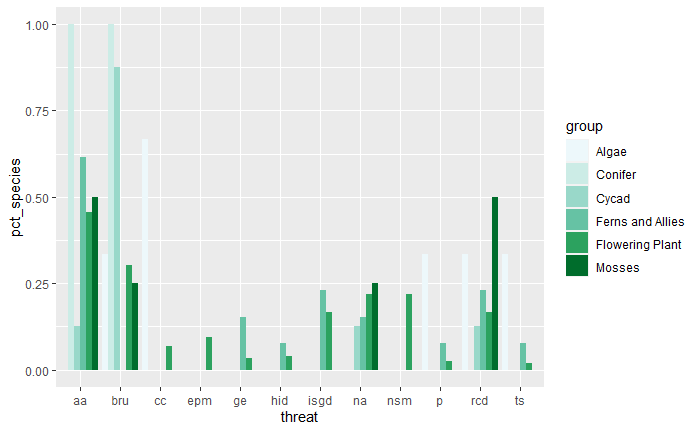

Just to get something on the, I’ll try doing many pie charts where each pie is a group/threat. I’m not sure how to approach such a heavily faceted graphic. Initially, a customized ggplot seems fine, but there has to be a better way… Well, let’s see. I still probably have to change the data so that there is a complement for every pie.

### Reviewing pie charts

Let’s start with the basic. I haven’t made a pie chart in a while, and in ggplot2 they aren’t the simplest because you have to convert to a polar coordinate system.

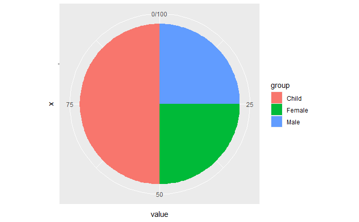

Maybe I can leverage the original data, or the `threats` data set so I don’t have to do a ton of data manipulation.

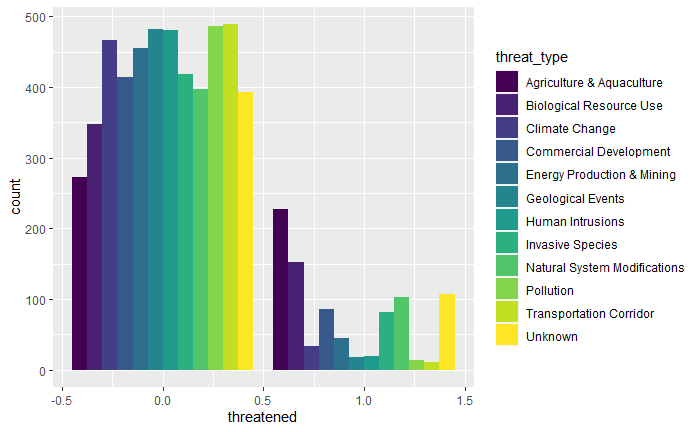

I’m happy with how this turned out – it’s what I asked for – I’m just not sure how to get this into the right groups.

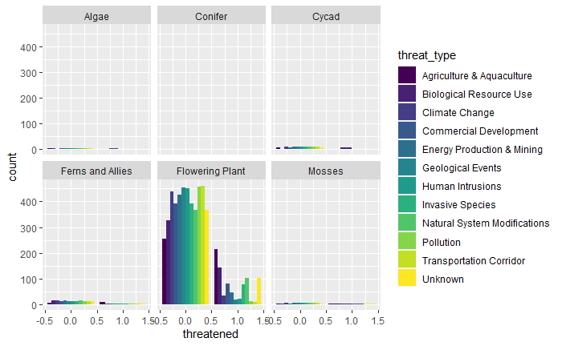

```r
threats %>%
  ggplot() +
  geom_bar(aes(x = threatened, group = threat_type, fill = threat_type),
           position = 'dodge') +
  scale_fill_viridis_d() +
  facet_wrap(vars(group))
```

Fine, but I need it to be relative.

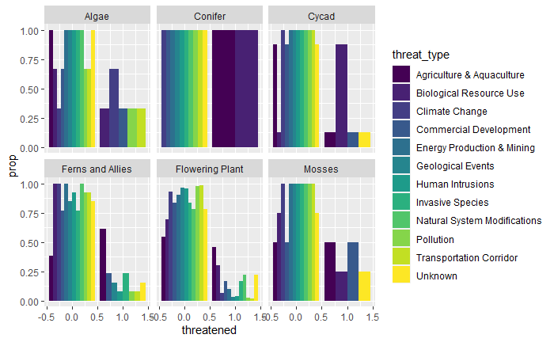

So, I guess this is getting warmer, but it’s still not great. This data is going to be heavily faceted; I need something else to work with here. Maybe I should create my own dataset after all, so I know what I’m working with. It’s a pretty bespoke graph, isn’t it?

Each pie chart has two parts, proportion yes and proportion no. This is done for each plant group, and for each type of threat.

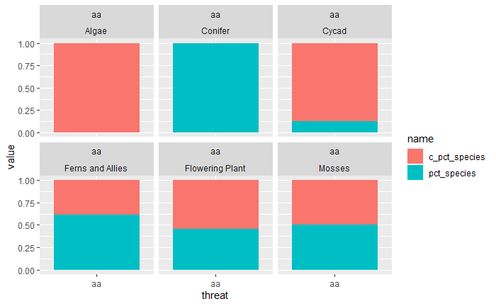

Perfect. Let’s see how polarizing goes.

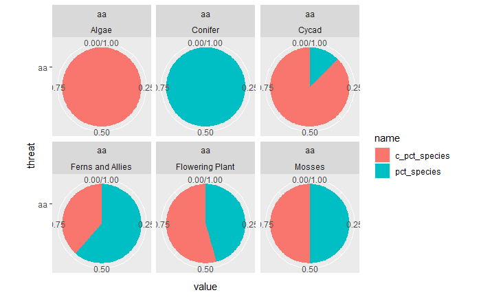

Beauty. Now, I restricted it to just the ‘aa’ threat (agriculture and aquaculture), because the banner is too large on each facet. Let me fix that by eliminating said banner.

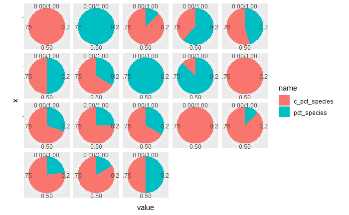

This works at the cost of losing the names for things. But I already have fairly large problems, beause I want to reorganize the circles into groups based on group. Maybe I’ll process them all separately.

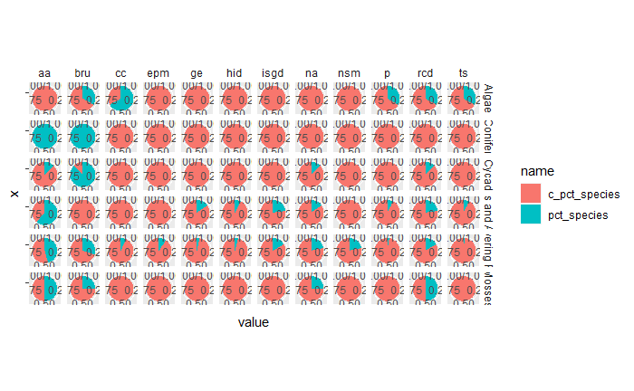

Okay, this is the basis on which I will base my final graphic. Boy, it’s gonna take some doing. But it’ll get there in no time.

# A day late, a dollar short

It’s now Wednesday, and I won’t have much time to work on this until later tonight, but for now I can try to figure out how I want this to look. Certainly, I need to change the aspect ratio. In fact, for this portion, I’m going to move to an R file, so I have more control.

See `rfiles\extinct_plants.R`.